# Analysis of Arousal (revised)

author

2026-11-11

# BRACKET INDEX (read this first)

The corrected Arousal paragraph has bracketed items that depend on the reruns in this file. Every bracket is computed below and marked in the code with `# >>> BRACKET Bx`. The last section prints all values in one table, ready to paste into the paragraph.

| Bracket | What it fills | Section in this file |
| --- | --- | --- |
| **B1** | Merge coverage: how many words/trials had norms; N participants | Merging with the norms |
| **B2** | Word-level valence-arousal correlation (replaces the trial-level r = -.19, CI [-.20, -.18]) | B2-B3 |
| **B3** | Quadratic fit / extremity / polarity (tests the V-shape) | B2-B3 |
| **B4** | Fit improvement over baseline for arousal and valence (replaces chi2(14) = 74.10 and 59.40) | Nested model comparisons |
| **B5** | AIC/BIC: arousal vs valence (replaces “delta AIC = 15”) | Nested model comparisons |
| **B6** | Does valence add beyond arousal? Does arousal add beyond valence? (replaces the invalid “combined model” test) | Nested model comparisons |
| **B7** | Pooled Task x Arousal: LRT, simple slopes, slope difference (replaces 0.0158 / -0.0179 / 0.0337) | Pooled Task x covariate tests |
| **B8** | Pooled Task x Valence: the equivalent test that was never run | Pooled Task x covariate tests |
| **B9** | Heterogeneity across experiments, Holm-corrected by-experiment contrasts | Heterogeneity |
| **B10** | Task effect adjusted for arousal vs unadjusted (replaces 0.158 vs 0.159), including Ex3 | Task effect after adjusting |

**What changed relative to arousal.Rmd (all deliberate):**

1. Exclusions are computed on ALL words first, then the norms are merged (arousal.Rmd merged first, so exclusions were computed on a reduced item set and the participants differed from the main analysis).
2. Norms are merged by Word (they are word properties), with a conflict check; the original merge by Word + Experiment dropped 42 words. Set `merge_mode <- "strict"` to reproduce the original behaviour.
3. Arousal and valence are mean-centred, so lower-order terms refer to average arousal/valence.
4. Models use the paper’s random-effects structure (by-participant and by-word Task slopes), falling back to simpler structures only if the larger one is singular. All models use ML so they can be compared.
5. Task is contrast-coded (TruthCond = -0.5, Valence = +0.5) and Experiment is sum-coded, so interaction terms are averages across experiments, not effects in the reference experiment (Ex1a).
6. The “combined model” (additive, not nested) is replaced by properly nested comparisons.
7. Correlations are computed on unique words, not trials.

**Runtime:** the three-way models with random slopes can take several minutes each.

# Configuration

```r
# ---- EDIT THIS BLOCK ---------------------------------------------------------
merge_mode        <- "word"   # "word" = merge norms by Word only (recommended); "strict" = Word + Experiment (original)
re_struct_override <- NULL    # NULL = pick automatically (maximal, then uncorrelated, then intercept-only)
                              # or force one of "maximal", "uncorrelated", "intercept"
valence_midpoint  <- 5        # midpoint of the Warriner 1-9 valence scale
# ------------------------------------------------------------------------------

stopifnot(merge_mode %in% c("word", "strict"))
stopifnot(all(c("Word", "Experiment", "V.Mean.Sum", "A.Mean.Sum") %in% names(arousal)))
```

# Remove outliers

CHANGE: exclusions are now applied to the full data `d` (all words), as in the main analysis, before merging the norms.

```r
# First remove inaccurate participants
length(unique(d$ID.true))
```

```
## [1] 276
```

```r
inacc.parts <- d %>%
  group_by(Experiment,ID.true,Task,Category) %>%
  summarise(MeanAccuracy = mean(Accuracy), .groups = "drop") %>%
  filter(MeanAccuracy < .75)
# How many participants have Accuracy < .75?
length(unique(inacc.parts$ID.true))
```

```
## [1] 41
```

```r
# Remove them
d.inaccurate.removed <- d %>%
  anti_join(inacc.parts, by = "ID.true")
# Sanity check
length(unique(d.inaccurate.removed$ID.true))
```

```
## [1] 235
```

```r
# Second, remove all inaccurate trials
orig <- nrow(d.inaccurate.removed)
d.inaccurate.removed <- d.inaccurate.removed %>%
  filter(Accuracy == 1)
nrow(d.inaccurate.removed)/orig*100
```

```
## [1] 94.15236
```

```r
quantile(d.inaccurate.removed$LogReactionTime, na.rm = TRUE)
```

```
##        0%       25%       50%       75%      100%
##  1.098612  6.440947  6.620073  6.879356 13.817820
```

```r
cutoff.high <- quantile(d.inaccurate.removed$LogReactionTime, na.rm = TRUE)[4] + IQR(d.inaccurate.removed$LogReactionTime, na.rm = TRUE)*3
cutoff.low <- quantile(d.inaccurate.removed$LogReactionTime, na.rm = TRUE)[2] - IQR(d.inaccurate.removed$LogReactionTime, na.rm = TRUE)*3

# remove trials with log RT outside 3 x IQR
df.outliers.removed <- subset(d.inaccurate.removed, (d.inaccurate.removed$LogReactionTime > cutoff.low) & (d.inaccurate.removed$LogReactionTime < cutoff.high))
final <- df.outliers.removed
```

# Merging with the norms

```r
# Norms are properties of the word, so the same word should have the same values in every experiment.
norm_conflicts <- arousal %>%
  group_by(Word) %>%
  summarise(n_V = n_distinct(V.Mean.Sum), n_A = n_distinct(A.Mean.Sum), .groups = "drop") %>%
  filter(n_V > 1 | n_A > 1)
cat("Words with conflicting norms across experiments:", nrow(norm_conflicts), "\n")
```

```
## Words with conflicting norms across experiments: 0
```

```r
if (merge_mode == "word" && nrow(norm_conflicts) > 0) {
  stop("Some words have different norms in different experiments; merging by Word alone is unsafe. ",
       "Inspect norm_conflicts or set merge_mode <- 'strict'.")
}

if (merge_mode == "word") {
  norms <- arousal %>%
    group_by(Word) %>%
    summarise(V.Mean.Sum = first(V.Mean.Sum), A.Mean.Sum = first(A.Mean.Sum), .groups = "drop")
  dn <- final %>% left_join(norms, by = "Word")
} else {
  norms <- arousal %>% select(Word, Experiment, V.Mean.Sum, A.Mean.Sum) %>% distinct()
  dn <- final %>% left_join(norms, by = c("Word", "Experiment"))
}

# Coverage diagnostics
cov_items <- dn %>%
  distinct(Experiment, Word, V.Mean.Sum, A.Mean.Sum) %>%
  mutate(matched = !is.na(V.Mean.Sum) & !is.na(A.Mean.Sum))
cov_words <- dn %>%
  group_by(Word) %>%
  summarise(matched = all(!is.na(V.Mean.Sum) & !is.na(A.Mean.Sum)), .groups = "drop")

n_items_total   <- nrow(cov_items);  n_items_matched <- sum(cov_items$matched)
n_words_total   <- nrow(cov_words);  n_words_matched <- sum(cov_words$matched)
n_trials_total  <- nrow(dn)
n_trials_lost   <- sum(is.na(dn$V.Mean.Sum) | is.na(dn$A.Mean.Sum))

cov_items %>%
  group_by(Experiment) %>%
  summarise(items = n(), matched = sum(matched), .groups = "drop") %>%
  knitr::kable(caption = "Items with norms, by experiment")
```

Items with norms, by experiment

| Experiment | items | matched |
| --- | --- | --- |
| Ex1a: Conc-Abs (Verbs) | 40 | 40 |
| Ex1b: Conc-Abs (Nouns) | 40 | 38 |
| Ex1c: Conc-Abs (Adjs) | 40 | 40 |
| Ex2a: Phys-Psych (Verbs) | 40 | 38 |
| Ex2b: Phys-Soc (Adjs) | 40 | 7 |
| Ex3: Animacy (Nouns) | 40 | 40 |
| Ex4: Syntactic (N v. V) | 40 | 37 |

```r
# Words that still have no norms: are they in the norms file under a different spelling/form?
unmatched_words <- cov_words %>% filter(!matched) %>%
  mutate(in_norms_file = Word %in% arousal$Word)
print(unmatched_words, n = Inf)
```

```
## # A tibble: 39 × 3
##    Word         matched in_norms_file
##    <chr>        <lgl>   <lgl>
##  1 brotherly    FALSE   FALSE
##  2 carefree     FALSE   FALSE
##  3 cheerful     FALSE   FALSE
##  4 comatose     FALSE   FALSE
##  5 corrode      FALSE   FALSE
##  6 courageous   FALSE   FALSE
##  7 decorative   FALSE   FALSE
##  8 dependable   FALSE   FALSE
##  9 dreaded      FALSE   FALSE
## 10 easygoing    FALSE   FALSE
## 11 excruciating FALSE   FALSE
## 12 fester       FALSE   FALSE
```

[output cut: 27 more lines]

```r
# Words with in_norms_file == FALSE are missing from total_words_measures.csv (check spelling, e.g. 'lonliness',
# or inflected forms such as 'flowers' vs the lemma 'flower') and can be fixed by editing that file.

# >>> BRACKET B1 (values used in the final table): coverage and trials lost
dcen <- dn %>%
  filter(!is.na(V.Mean.Sum), !is.na(A.Mean.Sum), !is.na(LogReactionTime)) %>%
  mutate(
    Task       = ifelse(Task == "Valence", "Valence", "TruthCond"),
    Task       = factor(Task, levels = c("TruthCond", "Valence")),
    Word       = as.factor(Word),
    ID.true    = as.factor(ID.true),
    Experiment = droplevels(as.factor(Experiment)),
    cA         = A.Mean.Sum - mean(A.Mean.Sum),    # centred arousal
    cV         = V.Mean.Sum - mean(V.Mean.Sum)     # centred valence
  )
contrasts(dcen$Task)       <- matrix(c(-0.5, 0.5), ncol = 1)       # coefficient = Valence - TruthCond
contrasts(dcen$Experiment) <- contr.sum(nlevels(dcen$Experiment))  # lower-order terms = averages across experiments
n_participants <- n_distinct(dcen$ID.true)
n_participants
```

```
## [1] 235
```

# B2-B3: Are arousal and valence correlated? (word level)

arousal.Rmd computed the correlation over trials (df = 44,677), which makes the CI and p-value far too tight for a claim about the stimulus set. Here it is computed over unique words.

```r
w <- dcen %>% distinct(Word, V.Mean.Sum, A.Mean.Sum)
n_w <- nrow(w)

# >>> BRACKET B2: word-level correlation (and the trial-level value for comparison)
cor_word  <- cor.test(w$V.Mean.Sum, w$A.Mean.Sum)
cor_trial <- cor.test(dcen$V.Mean.Sum, dcen$A.Mean.Sum)
cor_word
```

```
##
##  Pearson's product-moment correlation
##
## data:  w$V.Mean.Sum and w$A.Mean.Sum
## t = -3.1873, df = 192, p-value = 0.001677
## alternative hypothesis: true correlation is not equal to 0
## 95 percent confidence interval:
##  -0.35386986 -0.08601161
## sample estimates:
##        cor
## -0.2241702
```

```r
cor_trial
```

```
##
##  Pearson's product-moment correlation
##
## data:  dcen$V.Mean.Sum and dcen$A.Mean.Sum
## t = -41.371, df = 45327, p-value < 2.2e-16
## alternative hypothesis: true correlation is not equal to 0
## 95 percent confidence interval:
##  -0.1996081 -0.1818664
## sample estimates:
##        cor
## -0.1907529
```

```r
# >>> BRACKET B3: is the relationship V-shaped? (quadratic vs linear, extremity, polarity)
lin    <- lm(A.Mean.Sum ~ V.Mean.Sum, data = w)
quad   <- lm(A.Mean.Sum ~ poly(V.Mean.Sum, 2), data = w)
an_q   <- anova(lin, quad)
an_q
```

```
## Analysis of Variance Table
##
## Model 1: A.Mean.Sum ~ V.Mean.Sum
## Model 2: A.Mean.Sum ~ poly(V.Mean.Sum, 2)
##   Res.Df    RSS Df Sum of Sq      F    Pr(>F)
## 1    192 137.68
## 2    191 119.81  1    17.864 28.478 2.668e-07 ***
## ---
## Signif. codes:  0 '***' 0.001 '**' 0.01 '*' 0.05 '.' 0.1 ' ' 1
```

```r
w <- w %>% mutate(extremity = abs(V.Mean.Sum - valence_midpoint),
                  polarity  = ifelse(V.Mean.Sum > valence_midpoint, "positive", "negative"))
cor_ext <- cor.test(w$extremity, w$A.Mean.Sum)
cor_ext
```

```
##
##  Pearson's product-moment correlation
##
## data:  w$extremity and w$A.Mean.Sum
## t = 4.745, df = 192, p-value = 4.063e-06
## alternative hypothesis: true correlation is not equal to 0
## 95 percent confidence interval:
##  0.1918523 0.4445566
## sample estimates:
##       cor
## 0.3239711
```

```r
pol_tbl <- w %>% group_by(polarity) %>%
  summarise(n = n(), mean_A = mean(A.Mean.Sum), sd_A = sd(A.Mean.Sum), .groups = "drop")
knitr::kable(pol_tbl, digits = 2, caption = "Arousal by polarity (words)")
```

Arousal by polarity (words)

| polarity | n | mean_A | sd_A |
| --- | --- | --- | --- |
| negative | 101 | 4.91 | 0.74 |
| positive | 93 | 4.48 | 0.94 |

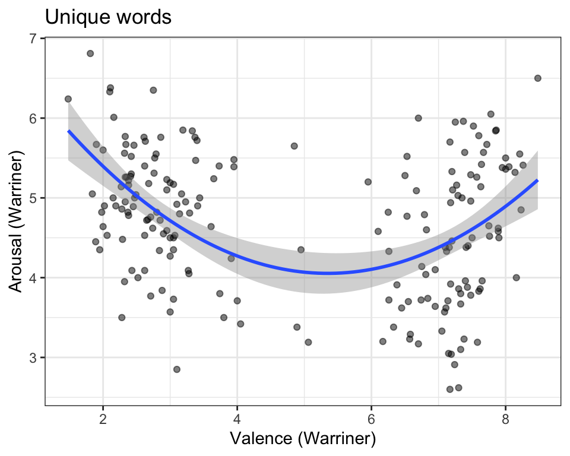

```r
ggplot(w, aes(x = V.Mean.Sum, y = A.Mean.Sum)) +
  geom_point(alpha = 0.5) +
  geom_smooth(method = "lm", formula = y ~ poly(x, 2), se = TRUE) +
  labs(x = "Valence (Warriner)", y = "Arousal (Warriner)", title = "Unique words")
```

# Models

Models are fit with ML so that likelihood-ratio tests are valid. The random-effects structure is chosen once, using the largest arousal model, and then used for all models so comparisons are like-for-like.

```r
re_terms <- list(
  maximal      = "(1 + Task | ID.true) + (1 + Task | Word)",
  uncorrelated = "(1 + Task || ID.true) + (1 + Task || Word)",
  intercept    = "(1 | ID.true) + (1 | Word)"
)

fit_ml <- function(rhs, re_struct) {
  fml <- as.formula(paste("LogReactionTime ~", rhs, "+", re_terms[[re_struct]]))
  lmer(fml, data = dcen, REML = FALSE,
       control = lmerControl(optimizer = "bobyqa", optCtrl = list(maxfun = 2e5)))
}

rhs <- list(
  base    = "Task * Experiment",
  A0      = "Task * Experiment + cA",
  A       = "Task * Experiment + cA * Task",
  V0      = "Task * Experiment + cV",
  V       = "Task * Experiment + cV * Task",
  AV      = "Task * Experiment + (cA + cV) * Task",
  A_het0  = "Task * Experiment + cA * Experiment + cA * Task",
  V_het0  = "Task * Experiment + cV * Experiment + cV * Task",
  A_full  = "Task * Experiment * cA",
  V_full  = "Task * Experiment * cV",
  AV_full = "Task * Experiment * (cA + cV)"
)

# Choose the random-effects structure using the largest arousal model
m_sel <- NULL
if (is.null(re_struct_override)) {
  for (s in names(re_terms)) {
    m_try <- fit_ml(rhs$A_full, s)
    if (!isSingular(m_try) || s == "intercept") { re_struct <- s; m_sel <- m_try; break }
  }
} else {
  re_struct <- re_struct_override
  m_sel <- fit_ml(rhs$A_full, re_struct)
}
cat("Random-effects structure used for ALL models:", re_struct, "\n")
```

```
## Random-effects structure used for ALL models: maximal
```

```r
models <- list(A_full = m_sel)
for (nm in setdiff(names(rhs), "A_full")) models[[nm]] <- fit_ml(rhs[[nm]], re_struct)
```

# Nested model comparisons

```r
lrt <- function(label, small, big, bracket) {
  a <- anova(models[[small]], models[[big]])
  tibble(bracket = bracket, test = label, small = small, big = big,
         chisq = a$Chisq[2], df = a$Df[2], p = a$`Pr(>Chisq)`[2])
}

lrt_tbl <- bind_rows(
  # >>> BRACKET B4 (replaces chi2(14) = 74.10 and 59.40)
  lrt("arousal (Task x Experiment x Arousal) vs baseline", "base", "A_full", "B4"),
  lrt("valence (Task x Experiment x Valence) vs baseline", "base", "V_full", "B4"),
  # >>> BRACKET B6 (replaces the invalid 'combined model' comparison)
  lrt("valence adds beyond arousal (pooled)",  "A", "AV", "B6"),
  lrt("arousal adds beyond valence (pooled)",  "V", "AV", "B6"),
  lrt("valence adds beyond arousal (full)",    "A_full", "AV_full", "B6"),
  lrt("arousal adds beyond valence (full)",    "V_full", "AV_full", "B6"),
  # >>> BRACKET B7 / B8 (pooled Task x covariate)
  lrt("pooled arousal main effect + Task x Arousal", "base", "A",  "B7"),
  lrt("pooled Task x Arousal (given arousal main effect)", "A0", "A", "B7"),
  lrt("pooled valence main effect + Task x Valence", "base", "V",  "B8"),
  lrt("pooled Task x Valence (given valence main effect)", "V0", "V", "B8"),
  # >>> BRACKET B9 (heterogeneity across experiments)
  lrt("Task x Arousal differs across experiments", "A_het0", "A_full", "B9"),
  lrt("Task x Valence differs across experiments", "V_het0", "V_full", "B9")
)
knitr::kable(lrt_tbl, digits = 4, caption = "Likelihood-ratio tests (all models fit with ML, same random effects)")
```

Likelihood-ratio tests (all models fit with ML, same random effects)

| bracket | test | small | big | chisq | df | p |
| --- | --- | --- | --- | --- | --- | --- |
| B4 | arousal (Task x Experiment x Arousal) vs baseline | base | A_full | 22.5210 | 14 | 0.0685 |
| B4 | valence (Task x Experiment x Valence) vs baseline | base | V_full | 26.8605 | 14 | 0.0201 |
| B6 | valence adds beyond arousal (pooled) | A | AV | 10.4374 | 2 | 0.0054 |
| B6 | arousal adds beyond valence (pooled) | V | AV | 13.9699 | 2 | 0.0009 |
| B6 | valence adds beyond arousal (full) | A_full | AV_full | 33.4122 | 14 | 0.0025 |
| B6 | arousal adds beyond valence (full) | V_full | AV_full | 29.0727 | 14 | 0.0102 |
| B7 | pooled arousal main effect + Task x Arousal | base | A | 10.0716 | 2 | 0.0065 |
| B7 | pooled Task x Arousal (given arousal main effect) | A0 | A | 3.9935 | 1 | 0.0457 |
| B8 | pooled valence main effect + Task x Valence | base | V | 6.5390 | 2 | 0.0380 |
| B8 | pooled Task x Valence (given valence main effect) | V0 | V | 0.0813 | 1 | 0.7756 |
| B9 | Task x Arousal differs across experiments | A_het0 | A_full | 2.1455 | 6 | 0.9058 |
| B9 | Task x Valence differs across experiments | V_het0 | V_full | 15.1536 | 6 | 0.0191 |

## B5: arousal vs valence (same number of parameters, so compare information criteria; not a nested test)

```r
npar <- function(m) attr(logLik(m), "df")
ic_tbl <- tibble(
  model = c("arousal (full)", "valence (full)", "arousal (pooled)", "valence (pooled)"),
  npar  = c(npar(models$A_full), npar(models$V_full), npar(models$A), npar(models$V)),
  AIC   = c(AIC(models$A_full), AIC(models$V_full), AIC(models$A), AIC(models$V)),
  BIC   = c(BIC(models$A_full), BIC(models$V_full), BIC(models$A), BIC(models$V))
)
ic_tbl <- ic_tbl %>%
  mutate(group = c("full", "full", "pooled", "pooled")) %>%
  group_by(group) %>%
  mutate(dAIC = AIC - min(AIC), dBIC = BIC - min(BIC)) %>%
  ungroup()
knitr::kable(ic_tbl, digits = 1, caption = "Lower is better; d = difference from the better model within each pair")
```

Lower is better; d = difference from the better model within each pair

| model | npar | AIC | BIC | group | dAIC | dBIC |
| --- | --- | --- | --- | --- | --- | --- |
| arousal (full) | 35 | 19643.7 | 19949.0 | full | 4.3 | 4.3 |
| valence (full) | 35 | 19639.4 | 19944.6 | full | 0.0 | 0.0 |
| arousal (pooled) | 23 | 19632.2 | 19832.8 | pooled | 0.0 | 0.0 |
| valence (pooled) | 23 | 19635.7 | 19836.3 | pooled | 3.5 | 3.5 |

# Pooled Task x covariate tests

Slopes are averaged equally across experiments. `TruthCond - Valence` keeps the sign used in the original text.

```r
std_names <- function(df) {
  nm <- names(df)
  nm[grepl("\\.trend$|^estimate$|^emmean$", nm)] <- "est"
  nm[grepl("LCL$|^lower\\.CL$", nm)] <- "lo"
  nm[grepl("UCL$|^upper\\.CL$", nm)] <- "hi"
  nm[grepl("ratio$", nm)] <- "stat"
  names(df) <- nm
  df
}

slopes_pooled <- function(m, var) {
  emt <- emtrends(m, ~ Task, var = var)
  list(slopes   = std_names(as.data.frame(summary(emt, infer = c(TRUE, TRUE)))),
       contrast = std_names(as.data.frame(summary(pairs(emt), infer = c(TRUE, TRUE)))))
}

# >>> BRACKET B7: pooled Task x Arousal (replaces 0.0158 / -0.0179 / 0.0337)
sa <- slopes_pooled(models$A_full, "cA")
```

[output not shown]

[output not shown]

```
## NOTE: Results may be misleading due to involvement in interactions
```

```r
knitr::kable(sa$slopes,   digits = 4, caption = "Arousal slopes on log RT, by Task (pooled over experiments)")
```

Arousal slopes on log RT, by Task (pooled over experiments)

| Task | est | SE | df | lo | hi | stat | p.value |
| --- | --- | --- | --- | --- | --- | --- | --- |
| TruthCond | -0.0010 | 0.0079 | Inf | -0.0164 | 0.0144 | -0.1248 | 0.9007 |
| Valence | -0.0179 | 0.0061 | Inf | -0.0298 | -0.0059 | -2.9354 | 0.0033 |

```r
knitr::kable(sa$contrast, digits = 4, caption = "Arousal slope: TruthCond - Valence")
```

Arousal slope: TruthCond - Valence

| contrast | est | SE | df | lo | hi | stat | p.value |
| --- | --- | --- | --- | --- | --- | --- | --- |
| TruthCond - Valence | 0.0169 | 0.0092 | Inf | -0.0011 | 0.0349 | 1.8413 | 0.0656 |

```r
# >>> BRACKET B8: pooled Task x Valence (the equivalent test that was missing)
sv <- slopes_pooled(models$V_full, "cV")
```

[output not shown]

[output not shown]

```
## NOTE: Results may be misleading due to involvement in interactions
```

```r
knitr::kable(sv$slopes,   digits = 4, caption = "Valence slopes on log RT, by Task (pooled over experiments)")
```

Valence slopes on log RT, by Task (pooled over experiments)

| Task | est | SE | df | lo | hi | stat | p.value |
| --- | --- | --- | --- | --- | --- | --- | --- |
| TruthCond | -0.004 | 0.0029 | Inf | -0.0096 | 0.0017 | -1.3802 | 0.1675 |
| Valence | -0.004 | 0.0022 | Inf | -0.0084 | 0.0003 | -1.8111 | 0.0701 |

```r
knitr::kable(sv$contrast, digits = 4, caption = "Valence slope: TruthCond - Valence")
```

Valence slope: TruthCond - Valence

| contrast | est | SE | df | lo | hi | stat | p.value |
| --- | --- | --- | --- | --- | --- | --- | --- |
| TruthCond - Valence | 1e-04 | 0.0034 | Inf | -0.0065 | 0.0066 | 0.0217 | 0.9827 |

# Heterogeneity across experiments

By-experiment slope differences (TruthCond - Valence). `p_holm` corrects across the 7 experiments.

```r
slopes_by_exp <- function(m, var) {
  emt <- emtrends(m, ~ Task | Experiment, var = var)
  list(slopes = std_names(as.data.frame(summary(emt, infer = c(TRUE, TRUE)))),
       contrasts = std_names(as.data.frame(summary(pairs(emt), infer = c(TRUE, TRUE)))) %>%
         mutate(p_holm = p.adjust(p.value, "holm")))
}

# >>> BRACKET B9: by-experiment contrasts with Holm correction
hA <- slopes_by_exp(models$A_full, "cA")
```

[output not shown]

[output not shown]

```r
hV <- slopes_by_exp(models$V_full, "cV")
```

[output not shown]

```r
knitr::kable(hA$slopes,    digits = 4, caption = "Arousal slopes by Task and Experiment")
```

Arousal slopes by Task and Experiment

| Task | Experiment | est | SE | df | lo | hi | stat | p.value |
| --- | --- | --- | --- | --- | --- | --- | --- | --- |
| TruthCond | Ex1a: Conc-Abs (Verbs) | 0.0027 | 0.0122 | Inf | -0.0212 | 0.0266 | 0.2223 | 0.8241 |
| Valence | Ex1a: Conc-Abs (Verbs) | -0.0193 | 0.0100 | Inf | -0.0389 | 0.0002 | -1.9390 | 0.0525 |
| TruthCond | Ex1b: Conc-Abs (Nouns) | -0.0209 | 0.0141 | Inf | -0.0486 | 0.0067 | -1.4861 | 0.1373 |
| Valence | Ex1b: Conc-Abs (Nouns) | -0.0460 | 0.0119 | Inf | -0.0693 | -0.0227 | -3.8666 | 0.0001 |
| TruthCond | Ex1c: Conc-Abs (Adjs) | 0.0000 | 0.0151 | Inf | -0.0297 | 0.0296 | -0.0031 | 0.9975 |
| Valence | Ex1c: Conc-Abs (Adjs) | 0.0042 | 0.0117 | Inf | -0.0188 | 0.0272 | 0.3598 | 0.7190 |
| TruthCond | Ex2a: Phys-Psych (Verbs) | 0.0019 | 0.0135 | Inf | -0.0245 | 0.0283 | 0.1426 | 0.8866 |
| Valence | Ex2a: Phys-Psych (Verbs) | -0.0229 | 0.0110 | Inf | -0.0444 | -0.0014 | -2.0832 | 0.0372 |
| TruthCond | Ex2b: Phys-Soc (Adjs) | 0.0102 | 0.0282 | Inf | -0.0451 | 0.0655 | 0.3618 | 0.7175 |
| Valence | Ex2b: Phys-Soc (Adjs) | 0.0000 | 0.0226 | Inf | -0.0443 | 0.0443 | -0.0005 | 0.9996 |
| TruthCond | Ex3: Animacy (Nouns) | 0.0041 | 0.0162 | Inf | -0.0275 | 0.0358 | 0.2563 | 0.7977 |
| Valence | Ex3: Animacy (Nouns) | -0.0089 | 0.0125 | Inf | -0.0334 | 0.0156 | -0.7126 | 0.4761 |
| TruthCond | Ex4: Syntactic (N v. V) | -0.0049 | 0.0138 | Inf | -0.0318 | 0.0221 | -0.3524 | 0.7245 |
| Valence | Ex4: Syntactic (N v. V) | -0.0323 | 0.0119 | Inf | -0.0557 | -0.0089 | -2.7069 | 0.0068 |

```r
knitr::kable(hA$contrasts, digits = 4, caption = "Arousal slope difference (TruthCond - Valence), by Experiment, Holm-corrected")
```

Arousal slope difference (TruthCond - Valence), by Experiment, Holm-corrected

| contrast | Experiment | est | SE | df | lo | hi | stat | p.value | p_holm |
| --- | --- | --- | --- | --- | --- | --- | --- | --- | --- |
| TruthCond - Valence | Ex1a: Conc-Abs (Verbs) | 0.0220 | 0.0147 | Inf | -0.0068 | 0.0509 | 1.4988 | 0.1339 | 0.7957 |
| TruthCond - Valence | Ex1b: Conc-Abs (Nouns) | 0.0250 | 0.0175 | Inf | -0.0092 | 0.0593 | 1.4344 | 0.1515 | 0.7957 |
| TruthCond - Valence | Ex1c: Conc-Abs (Adjs) | -0.0043 | 0.0175 | Inf | -0.0386 | 0.0300 | -0.2437 | 0.8075 | 1.0000 |
| TruthCond - Valence | Ex2a: Phys-Psych (Verbs) | 0.0248 | 0.0162 | Inf | -0.0070 | 0.0565 | 1.5302 | 0.1260 | 0.7957 |
| TruthCond - Valence | Ex2b: Phys-Soc (Adjs) | 0.0102 | 0.0349 | Inf | -0.0581 | 0.0786 | 0.2931 | 0.7695 | 1.0000 |
| TruthCond - Valence | Ex3: Animacy (Nouns) | 0.0131 | 0.0187 | Inf | -0.0236 | 0.0497 | 0.6987 | 0.4847 | 1.0000 |
| TruthCond - Valence | Ex4: Syntactic (N v. V) | 0.0274 | 0.0173 | Inf | -0.0066 | 0.0614 | 1.5819 | 0.1137 | 0.7957 |

```r
knitr::kable(hV$contrasts, digits = 4, caption = "Valence slope difference (TruthCond - Valence), by Experiment, Holm-corrected")
```

Valence slope difference (TruthCond - Valence), by Experiment, Holm-corrected

| contrast | Experiment | est | SE | df | lo | hi | stat | p.value | p_holm |
| --- | --- | --- | --- | --- | --- | --- | --- | --- | --- |
| TruthCond - Valence | Ex1a: Conc-Abs (Verbs) | -0.0070 | 0.0055 | Inf | -0.0177 | 0.0038 | -1.2695 | 0.2043 | 0.8349 |
| TruthCond - Valence | Ex1b: Conc-Abs (Nouns) | 0.0082 | 0.0052 | Inf | -0.0021 | 0.0184 | 1.5567 | 0.1195 | 0.7172 |
| TruthCond - Valence | Ex1c: Conc-Abs (Adjs) | 0.0095 | 0.0069 | Inf | -0.0040 | 0.0230 | 1.3820 | 0.1670 | 0.8349 |
| TruthCond - Valence | Ex2a: Phys-Psych (Verbs) | 0.0015 | 0.0068 | Inf | -0.0118 | 0.0148 | 0.2275 | 0.8200 | 1.0000 |
| TruthCond - Valence | Ex2b: Phys-Soc (Adjs) | -0.0032 | 0.0127 | Inf | -0.0281 | 0.0217 | -0.2518 | 0.8012 | 1.0000 |
| TruthCond - Valence | Ex3: Animacy (Nouns) | -0.0128 | 0.0054 | Inf | -0.0234 | -0.0022 | -2.3593 | 0.0183 | 0.1282 |
| TruthCond - Valence | Ex4: Syntactic (N v. V) | 0.0043 | 0.0057 | Inf | -0.0070 | 0.0155 | 0.7414 | 0.4584 | 1.0000 |

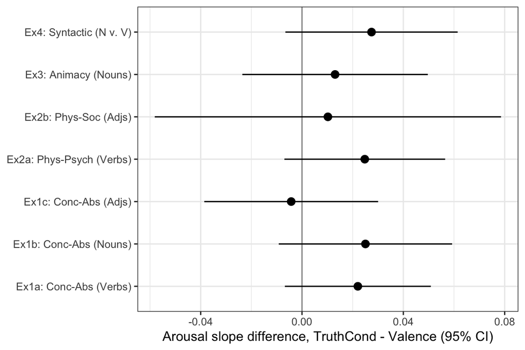

```r
ggplot(hA$contrasts, aes(x = est, y = Experiment)) +
  geom_vline(xintercept = 0, colour = "grey60") +
  geom_pointrange(aes(xmin = lo, xmax = hi)) +
  labs(x = "Arousal slope difference, TruthCond - Valence (95% CI)", y = NULL)
```

# Task effect after adjusting for arousal (B10)

The key question: does the valence advantage shrink once arousal is accounted for? Effects are Valence - TruthCond on log RT (negative = Valence faster), at average arousal/valence, averaged over experiments.

```r
task_effect <- function(m, label) {
  emm <- emmeans(m, ~ Task)
  std_names(as.data.frame(summary(contrast(emm, list("Valence - TruthCond" = c(-1, 1))),
                                  infer = c(TRUE, TRUE)))) %>%
    mutate(model = label, .before = 1)
}
task_effect_by_exp <- function(m, label) {
  emm <- emmeans(m, ~ Task | Experiment)
  std_names(as.data.frame(summary(contrast(emm, list("Valence - TruthCond" = c(-1, 1))),
                                  infer = c(TRUE, TRUE)))) %>%
    mutate(model = label, .before = 1)
}

# >>> BRACKET B10: adjusted vs unadjusted Task effect (replaces 0.158 vs 0.159)
te_pooled <- bind_rows(
  task_effect(models$base,   "unadjusted (baseline)"),
  task_effect(models$A_full, "adjusted for arousal"),
  task_effect(models$V_full, "adjusted for valence")
)
```

[output not shown]

[output not shown]

```
## NOTE: Results may be misleading due to involvement in interactions
```

[output not shown]

[output not shown]

```
## NOTE: Results may be misleading due to involvement in interactions
```

[output not shown]

[output not shown]

```
## NOTE: Results may be misleading due to involvement in interactions
```

```r
knitr::kable(te_pooled, digits = 3, caption = "Task effect on log RT, pooled over experiments")
```

Task effect on log RT, pooled over experiments

| model | contrast | est | SE | df | lo | hi | stat | p.value |
| --- | --- | --- | --- | --- | --- | --- | --- | --- |
| unadjusted (baseline) | Valence - TruthCond | -0.155 | 0.012 | Inf | -0.179 | -0.132 | -13.086 | 0 |
| adjusted for arousal | Valence - TruthCond | -0.155 | 0.012 | Inf | -0.179 | -0.132 | -13.099 | 0 |
| adjusted for valence | Valence - TruthCond | -0.157 | 0.012 | Inf | -0.181 | -0.134 | -13.146 | 0 |

```r
te_exp <- bind_rows(
  task_effect_by_exp(models$base,   "unadjusted (baseline)"),
  task_effect_by_exp(models$A_full, "adjusted for arousal")
)
```

[output not shown]

[output not shown]

[output not shown]

[output not shown]

```
## NOTE: Results may be misleading due to involvement in interactions
```

```r
te_exp %>%
  select(model, Experiment, est, SE, lo, hi) %>%
  knitr::kable(digits = 3, caption = "Task effect by experiment (check Ex3 in particular)")
```

Task effect by experiment (check Ex3 in particular)

| model | Experiment | est | SE | lo | hi |
| --- | --- | --- | --- | --- | --- |
| unadjusted (baseline) | Ex1a: Conc-Abs (Verbs) | -0.111 | 0.024 | -0.159 | -0.063 |
| unadjusted (baseline) | Ex1b: Conc-Abs (Nouns) | -0.143 | 0.024 | -0.190 | -0.097 |
| unadjusted (baseline) | Ex1c: Conc-Abs (Adjs) | -0.185 | 0.028 | -0.239 | -0.131 |
| unadjusted (baseline) | Ex2a: Phys-Psych (Verbs) | -0.190 | 0.025 | -0.239 | -0.142 |
| unadjusted (baseline) | Ex2b: Phys-Soc (Adjs) | -0.219 | 0.040 | -0.297 | -0.141 |
| unadjusted (baseline) | Ex3: Animacy (Nouns) | -0.040 | 0.026 | -0.091 | 0.012 |
| unadjusted (baseline) | Ex4: Syntactic (N v. V) | -0.200 | 0.028 | -0.255 | -0.145 |
| adjusted for arousal | Ex1a: Conc-Abs (Verbs) | -0.110 | 0.024 | -0.158 | -0.063 |
| adjusted for arousal | Ex1b: Conc-Abs (Nouns) | -0.141 | 0.024 | -0.187 | -0.095 |
| adjusted for arousal | Ex1c: Conc-Abs (Adjs) | -0.184 | 0.028 | -0.238 | -0.130 |
| adjusted for arousal | Ex2a: Phys-Psych (Verbs) | -0.194 | 0.025 | -0.243 | -0.145 |
| adjusted for arousal | Ex2b: Phys-Soc (Adjs) | -0.221 | 0.040 | -0.300 | -0.143 |
| adjusted for arousal | Ex3: Animacy (Nouns) | -0.038 | 0.027 | -0.090 | 0.014 |
| adjusted for arousal | Ex4: Syntactic (N v. V) | -0.199 | 0.028 | -0.253 | -0.145 |

# Values for the bracketed items (B1-B10)

Each value is computed inside `safe()`, so a failure in one bracket does not stop the knit. A value that begins with `<<could not compute` needs attention.

```r
safe  <- function(expr) tryCatch(expr, error = function(e) paste0("<<could not compute: ", conditionMessage(e), ">>"))
fmt_p <- function(p) ifelse(p < .001, "< .001", sprintf("= %.3f", p))
lrt_get <- function(s, b) lrt_tbl[lrt_tbl$small == s & lrt_tbl$big == b, ]
lrt_str <- function(r) sprintf("chi2(%d) = %.2f, p %s", as.integer(r$df), r$chisq, fmt_p(r$p))

B1 <- safe(sprintf(
  "%d of %d unique words matched the norms (%d of %d word-by-experiment items); %d of %d trials (%.1f%%) lacked norms and were dropped from the arousal analyses; N = %d participants after exclusions.",
  n_words_matched, n_words_total, n_items_matched, n_items_total,
  n_trials_lost, n_trials_total, 100 * n_trials_lost / n_trials_total, n_participants))

B2 <- safe(sprintf(
  "word level: r = %.2f, 95%% CI [%.2f, %.2f], p %s, n = %d words.  (trial level, for comparison: r = %.2f, 95%% CI [%.2f, %.2f], df = %d)",
  cor_word$estimate, cor_word$conf.int[1], cor_word$conf.int[2], fmt_p(cor_word$p.value), n_w,
  cor_trial$estimate, cor_trial$conf.int[1], cor_trial$conf.int[2], as.integer(cor_trial$parameter)))

B3 <- safe(sprintf(
  "quadratic vs linear fit: F(%d, %d) = %.2f, p %s; R2 = %.3f (linear) vs %.3f (quadratic); arousal vs valence extremity: r = %.2f, p %s; mean arousal = %.2f (positive words, n = %d) vs %.2f (negative words, n = %d).",
  as.integer(an_q$Df[2]), as.integer(an_q$Res.Df[2]), an_q$F[2], fmt_p(an_q$`Pr(>F)`[2]),
  summary(lin)$r.squared, summary(quad)$r.squared,
  cor_ext$estimate, fmt_p(cor_ext$p.value),
  pol_tbl$mean_A[pol_tbl$polarity == "positive"], pol_tbl$n[pol_tbl$polarity == "positive"],
  pol_tbl$mean_A[pol_tbl$polarity == "negative"], pol_tbl$n[pol_tbl$polarity == "negative"]))

B4 <- safe(sprintf("arousal vs baseline: %s;  valence vs baseline: %s",
                   lrt_str(lrt_get("base", "A_full")), lrt_str(lrt_get("base", "V_full"))))

B5 <- safe({
  f <- ic_tbl %>% filter(group == "full")
  sprintf("full models: AIC = %.0f (arousal) vs %.0f (valence), dAIC = %.1f; BIC = %.0f vs %.0f, dBIC = %.1f  (positive = arousal model is better)",
          f$AIC[f$model == "arousal (full)"], f$AIC[f$model == "valence (full)"],
          f$AIC[f$model == "valence (full)"] - f$AIC[f$model == "arousal (full)"],
          f$BIC[f$model == "arousal (full)"], f$BIC[f$model == "valence (full)"],
          f$BIC[f$model == "valence (full)"] - f$BIC[f$model == "arousal (full)"])
})

B6 <- safe(sprintf(
  "valence adds beyond arousal: %s (pooled), %s (full);  arousal adds beyond valence: %s (pooled), %s (full)",
  lrt_str(lrt_get("A", "AV")), lrt_str(lrt_get("A_full", "AV_full")),
  lrt_str(lrt_get("V", "AV")), lrt_str(lrt_get("V_full", "AV_full"))))

slope_str <- function(sl, ct, lr) {
  tc <- sl[sl$Task == "TruthCond", ]; va <- sl[sl$Task == "Valence", ]
  sprintf("slopes: TruthCond b = %.4f [%.4f, %.4f]; Valence b = %.4f [%.4f, %.4f]; difference (TruthCond - Valence) = %.4f, SE = %.4f, z = %.2f, p %s; LRT for the pooled interaction: %s",
          tc$est, tc$lo, tc$hi, va$est, va$lo, va$hi, ct$est, ct$SE, ct$stat, fmt_p(ct$p.value), lr)
}
B7 <- safe(slope_str(sa$slopes, sa$contrast, lrt_str(lrt_get("A0", "A"))))
B8 <- safe(slope_str(sv$slopes, sv$contrast, lrt_str(lrt_get("V0", "V"))))

het_str <- function(h) paste0(
  h$Experiment, ": ", sprintf("%.3f", h$est), " (Holm p ", fmt_p(h$p_holm), ")", collapse = "; ")
B9 <- safe(sprintf(
  "heterogeneity of Task x Arousal across experiments: %s.  By experiment (TruthCond - Valence arousal slope): %s.  [Valence, same test: %s; by experiment: %s]",
  lrt_str(lrt_get("A_het0", "A_full")), het_str(hA$contrasts),
  lrt_str(lrt_get("V_het0", "V_full")), het_str(hV$contrasts)))

B10 <- safe({
  g <- function(lbl) te_pooled[te_pooled$model == lbl, ]
  u <- g("unadjusted (baseline)"); a <- g("adjusted for arousal"); v <- g("adjusted for valence")
  e3 <- te_exp[grepl("Animacy", te_exp$Experiment), ]
  sprintf("Task effect (Valence - TruthCond, log RT, pooled): unadjusted %.3f [%.3f, %.3f]; adjusted for arousal %.3f [%.3f, %.3f]; adjusted for valence %.3f [%.3f, %.3f].  Ex3 (animacy): unadjusted %.3f, adjusted for arousal %.3f.",
          u$est, u$lo, u$hi, a$est, a$lo, a$hi, v$est, v$lo, v$hi,
          e3$est[e3$model == "unadjusted (baseline)"], e3$est[e3$model == "adjusted for arousal"])
})

bracket_values <- tibble(
  bracket = paste0("B", 1:10),
  replaces = c(
    "'We merged our stimuli with the Warriner norms [coverage]' (the original did not report the 42 dropped words)",
    "r = -.19, 95% CI [-.20, -.18], p < .0001 (trial level)",
    "(new) V-shape test at the word level",
    "chi2(14) = 74.10 (arousal) and 59.40 (valence)",
    "'arousal model had the lower AIC (dAIC = 15)'",
    "chi2(12) = 46.40 / 61.09 'combined model' comparison (invalid, non-nested)",
    "b = 0.0158, b = -0.0179, difference 0.0337, SE 0.0082, z = 4.10",
    "(new) the valence version of the pooled slope test",
    "'heterogeneous... strongest for concrete-abstract' (by-experiment list)",
    "Task effect 0.158 at average arousal vs 0.159 unadjusted"),
  value = c(B1, B2, B3, B4, B5, B6, B7, B8, B9, B10)
)
knitr::kable(bracket_values, caption = "Fill each [Bx] in the corrected paragraph with the value shown")
```

Fill each [Bx] in the corrected paragraph with the value shown

[output not shown]

```r
# Plain-text version for copy/paste
for (i in seq_len(nrow(bracket_values))) {
  cat(sprintf("**%s** (replaces: %s)\n\n%s\n\n", bracket_values$bracket[i], bracket_values$replaces[i], bracket_values$value[i]))
}
```

**B1** (replaces: ‘We merged our stimuli with the Warriner norms [coverage]’ (the original did not report the 42 dropped words))

194 of 233 unique words matched the norms (240 of 280 word-by-experiment items); 6964 of 52293 trials (13.3%) lacked norms and were dropped from the arousal analyses; N = 235 participants after exclusions.

**B2** (replaces: r = -.19, 95% CI [-.20, -.18], p < .0001 (trial level))

word level: r = -0.22, 95% CI [-0.35, -0.09], p = 0.002, n = 194 words. (trial level, for comparison: r = -0.19, 95% CI [-0.20, -0.18], df = 45327)

**B3** (replaces: (new) V-shape test at the word level)

quadratic vs linear fit: F(1, 191) = 28.48, p < .001; R2 = 0.050 (linear) vs 0.173 (quadratic); arousal vs valence extremity: r = 0.32, p < .001; mean arousal = 4.48 (positive words, n = 93) vs 4.91 (negative words, n = 101).

**B4** (replaces: chi2(14) = 74.10 (arousal) and 59.40 (valence))

arousal vs baseline: chi2(14) = 22.52, p = 0.069; valence vs baseline: chi2(14) = 26.86, p = 0.020

**B5** (replaces: ‘arousal model had the lower AIC (dAIC = 15)’)

full models: AIC = 19644 (arousal) vs 19639 (valence), dAIC = -4.3; BIC = 19949 vs 19945, dBIC = -4.3 (positive = arousal model is better)

**B6** (replaces: chi2(12) = 46.40 / 61.09 ‘combined model’ comparison (invalid, non-nested))

valence adds beyond arousal: chi2(2) = 10.44, p = 0.005 (pooled), chi2(14) = 33.41, p = 0.003 (full); arousal adds beyond valence: chi2(2) = 13.97, p < .001 (pooled), chi2(14) = 29.07, p = 0.010 (full)

**B7** (replaces: b = 0.0158, b = -0.0179, difference 0.0337, SE 0.0082, z = 4.10)

slopes: TruthCond b = -0.0010 [-0.0164, 0.0144]; Valence b = -0.0179 [-0.0298, -0.0059]; difference (TruthCond - Valence) = 0.0169, SE = 0.0092, z = 1.84, p = 0.066; LRT for the pooled interaction: chi2(1) = 3.99, p = 0.046

**B8** (replaces: (new) the valence version of the pooled slope test)

slopes: TruthCond b = -0.0040 [-0.0096, 0.0017]; Valence b = -0.0040 [-0.0084, 0.0003]; difference (TruthCond - Valence) = 0.0001, SE = 0.0034, z = 0.02, p = 0.983; LRT for the pooled interaction: chi2(1) = 0.08, p = 0.776

**B9** (replaces: ‘heterogeneous… strongest for concrete-abstract’ (by-experiment list))

heterogeneity of Task x Arousal across experiments: chi2(6) = 2.15, p = 0.906. By experiment (TruthCond - Valence arousal slope): Ex1a: Conc-Abs (Verbs): 0.022 (Holm p = 0.796); Ex1b: Conc-Abs (Nouns): 0.025 (Holm p = 0.796); Ex1c: Conc-Abs (Adjs): -0.004 (Holm p = 1.000); Ex2a: Phys-Psych (Verbs): 0.025 (Holm p = 0.796); Ex2b: Phys-Soc (Adjs): 0.010 (Holm p = 1.000); Ex3: Animacy (Nouns): 0.013 (Holm p = 1.000); Ex4: Syntactic (N v. V): 0.027 (Holm p = 0.796). [Valence, same test: chi2(6) = 15.15, p = 0.019; by experiment: Ex1a: Conc-Abs (Verbs): -0.007 (Holm p = 0.835); Ex1b: Conc-Abs (Nouns): 0.008 (Holm p = 0.717); Ex1c: Conc-Abs (Adjs): 0.010 (Holm p = 0.835); Ex2a: Phys-Psych (Verbs): 0.002 (Holm p = 1.000); Ex2b: Phys-Soc (Adjs): -0.003 (Holm p = 1.000); Ex3: Animacy (Nouns): -0.013 (Holm p = 0.128); Ex4: Syntactic (N v. V): 0.004 (Holm p = 1.000)]

**B10** (replaces: Task effect 0.158 at average arousal vs 0.159 unadjusted)

Task effect (Valence - TruthCond, log RT, pooled): unadjusted -0.155 [-0.179, -0.132]; adjusted for arousal -0.155 [-0.179, -0.132]; adjusted for valence -0.157 [-0.181, -0.134]. Ex3 (animacy): unadjusted -0.040, adjusted for arousal -0.038.

# Corrected paragraph template

Replace each `[Bx]` with the value above. Keep only claims the reruns support: in particular, drop “arousal, but not valence” unless B8 shows no pooled Task x Valence effect, and drop “Arousal does not account for the valence advantage” unless B10 shows the adjusted Task effect is close to the unadjusted one in the refit models.

> A second possibility is that our results are driven by arousal rather than valence. This is relevant because we selected words with extreme valence ratings, and arousal tends to be higher for extreme valence (Russell, 1980; Warriner et al., 2013; Yik et al., 2023). We merged our stimuli with the Warriner et al. (2013) norms **[B1]**. At the word level, valence and arousal were correlated, **[B2]**, and **[B3]**.